# **Bank Churn Prediction Project**

#### **Once again borrowing function from MLS class instead of creating my own**

```python
# function to plot stacked bar chart


def stacked_barplot(data, predictor, target):
    """
    Print the category counts and plot a stacked bar chart

    data: dataframe
    predictor: independent variable
    target: target variable
    """
    count = data[predictor].nunique()
    sorter = data[target].value_counts().index[-1]
    tab1 = pd.crosstab(data[predictor], data[target], margins=True).sort_values(
        by=sorter, ascending=False
    )
    print(tab1)
    print("-" * 120)
    tab = pd.crosstab(data[predictor], data[target], normalize="index").sort_values(
        by=sorter, ascending=False
    )
    tab.plot(kind="bar", stacked=True, figsize=(count + 1, 5))
    plt.legend(
        loc="lower left",
        frameon=False,
    )
    plt.legend(loc="upper left", bbox_to_anchor=(1, 1))
    plt.show()
```

```python
### Function to plot distributions


def distribution_plot_wrt_target(data, predictor, target):

    fig, axs = plt.subplots(2, 2, figsize=(12, 10))

    target_uniq = data[target].unique()

    axs[0, 0].set_title("Distribution of target for " + target + "=" + str(target_uniq[0]))
    sns.histplot(
        data=data[data[target] == target_uniq[0]],
        x=predictor,
        kde=True,
        ax=axs[0, 0],
        color="teal",
    )

    axs[0, 1].set_title("Distribution of target for " + target + "=" + str(target_uniq[1]))
    sns.histplot(
        data=data[data[target] == target_uniq[1]],
        x=predictor,
        kde=True,
        ax=axs[0, 1],
        color="orange",
    )

    axs[1, 0].set_title("Boxplot w.r.t target")
    sns.boxplot(data=data, x=target, y=predictor, ax=axs[1, 0], palette="gist_rainbow")

    axs[1, 1].set_title("Boxplot (without outliers) w.r.t target")
    sns.boxplot(
        data=data,
        x=target,
        y=predictor,
        ax=axs[1, 1],
        showfliers=False,
        palette="gist_rainbow",
    )

    plt.tight_layout()
    plt.show()
```

```
Exited     0     1    All
Tenure
All     7963  2037  10000
1        803   232   1035
3        796   213   1009
9        771   213    984
5        803   209   1012
4        786   203    989
2        847   201   1048
8        828   197   1025
6        771   196    967
7        851   177   1028
10       389   101    490
0        318    95    413
------------------------------------------------------------------------------------------------------------------------
```

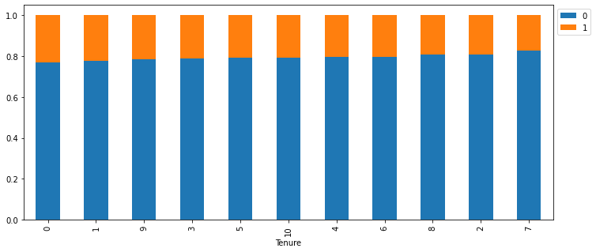

```python
# Let's get a stacked bar graph to get an idea of the risk of exit based on how long a customer had tenure with the bank
stacked_barplot(df, 'Tenure', 'Exited')
```

The tenure data doesn't seem to have any significant impact on customers exitin the bank. New and old customers tend to exit at the same rate.

```
Exited            0     1    All
NumOfProducts
All            7963  2037  10000
1              3675  1409   5084
2              4242   348   4590
3                46   220    266
4                 0    60     60
------------------------------------------------------------------------------------------------------------------------
```

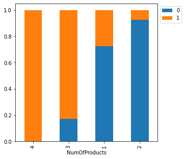

```python
# Stacked bar graph to look closely at the relationship of risk of exit to the number of bank products owned by customer
stacked_barplot(df, 'NumOfProducts', 'Exited')
```

```
Exited        0     1    All
HasCrCard
All        7963  2037  10000
1          5631  1424   7055
0          2332   613   2945
------------------------------------------------------------------------------------------------------------------------
```

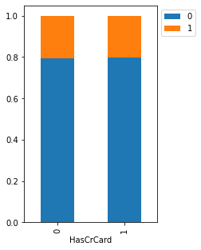

```python
stacked_barplot(df, 'HasCrCard', 'Exited')
```

No significant insights here.

```
Exited             0     1    All
IsActiveMember
All             7963  2037  10000
0               3547  1302   4849
1               4416   735   5151
------------------------------------------------------------------------------------------------------------------------
```

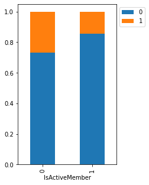

```python
stacked_barplot(df, 'IsActiveMember', 'Exited')
```

No surprise here. Less active members are more likely to exit. Bank has to engage with them.

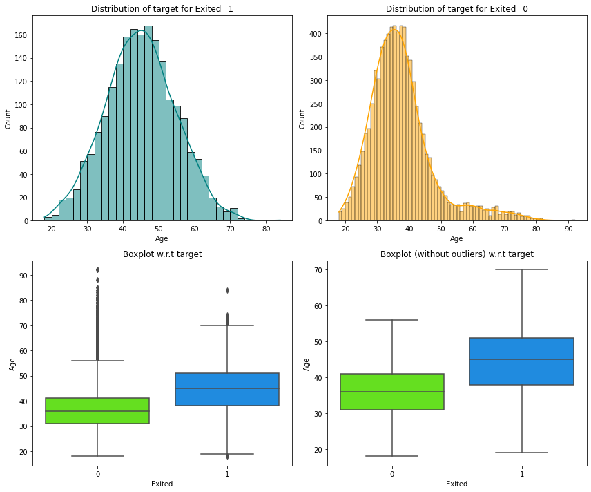

```python
distribution_plot_wrt_target(df, "Age", "Exited")
```

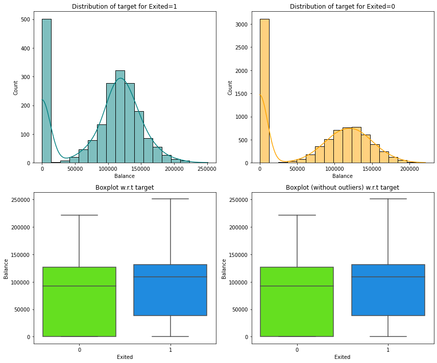

```python
distribution_plot_wrt_target(df, "Balance", "Exited")
```

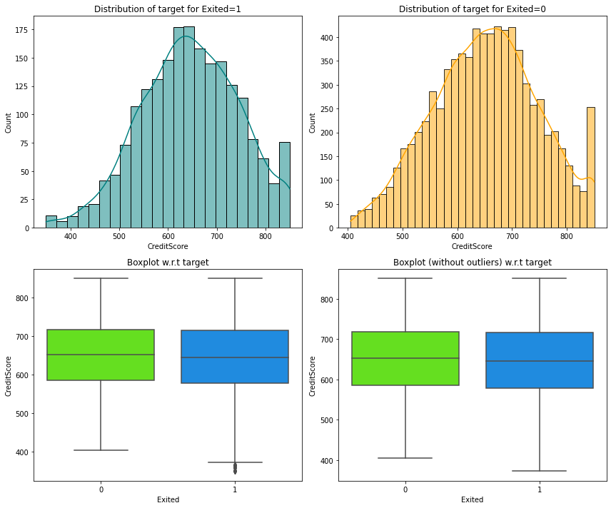

```python
distribution_plot_wrt_target(df, "CreditScore", "Exited")
```

Credit score appears to have no impact on a person's decision to stay with the bank or to switch.

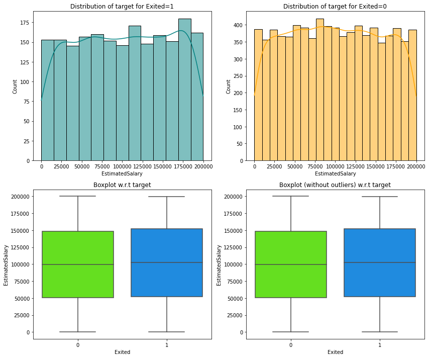

```python
distribution_plot_wrt_target(df, "EstimatedSalary", "Exited")
```

Estimated salary also seems to have no impact on a person's choice to stay with the bank or to leave.

## **Insights Based on EDA**

The EDA reveals the following items about the customers and their choice to stay or leave

- Most independent variables appear to have no correlation with bank.
- The customers between 40-50 are more liley to leave the bank and the bank needs to engage with them.
- Less active customers are slightly more inclined to leave the bank, so bank managers need to keep an accounts with less activity.
- In general, a lack of correlation with the target variable means that it is very difficult to predict which customers are likely to leave those who are likely to stay. Linear separability is difficult to achieve for this data set.
- We will need to utilize the power of the neural network to discover realtionships that are otherwise not visiable from looking at the data. There may be relationships between the target varaible and the features on a higher dimension.

## **Feature Engineering**

Let's do one-hot-encoding for the two categorical columns `Gender` and `Geography`

```python
encoded_df = pd.get_dummies(df, drop_first=True, columns=['Gender', 'Geography'])
```

```python
encoded_df.head()
```

|  | CreditScore | Age | Tenure | Balance | NumOfProducts | HasCrCard | IsActiveMember | EstimatedSalary | Exited | Gender_Male | Geography_Germany | Geography_Spain |
| --- | --- | --- | --- | --- | --- | --- | --- | --- | --- | --- | --- | --- |
| 0 | 619 | 42 | 2 | 0.000 | 1 | 1 | 1 | 101348.880 | 1 | 0 | 0 | 0 |
| 1 | 608 | 41 | 1 | 83807.860 | 1 | 0 | 1 | 112542.580 | 0 | 0 | 0 | 1 |
| 2 | 502 | 42 | 8 | 159660.800 | 3 | 1 | 0 | 113931.570 | 1 | 0 | 0 | 0 |
| 3 | 699 | 39 | 1 | 0.000 | 2 | 0 | 0 | 93826.630 | 0 | 0 | 0 | 0 |
| 4 | 850 | 43 | 2 | 125510.820 | 1 | 1 | 1 | 79084.100 | 0 | 0 | 0 | 1 |

```python
# The 0.0 balance is going to mess up our predictions. We need to impute the 0 values with NaN to help with the imputation.
# The impute itself needs to be done on the train, validation, and test sets separately in order not to cause data leakage.
# Here all we have done is prepared the data for imputation; rest of the feature engineeting will be done after data split.

encoded_df["Balance"].replace(0.000, np.nan, inplace=True)
```

```python
# Verify that we indeed got the NaN data in the `Balance` column
encoded_df.head()
```

|  | CreditScore | Age | Tenure | Balance | NumOfProducts | HasCrCard | IsActiveMember | EstimatedSalary | Exited | Gender_Male | Geography_Germany | Geography_Spain |
| --- | --- | --- | --- | --- | --- | --- | --- | --- | --- | --- | --- | --- |
| 0 | 619 | 42 | 2 | nan | 1 | 1 | 1 | 101348.880 | 1 | 0 | 0 | 0 |
| 1 | 608 | 41 | 1 | 83807.860 | 1 | 0 | 1 | 112542.580 | 0 | 0 | 0 | 1 |
| 2 | 502 | 42 | 8 | 159660.800 | 3 | 1 | 0 | 113931.570 | 1 | 0 | 0 | 0 |
| 3 | 699 | 39 | 1 | nan | 2 | 0 | 0 | 93826.630 | 0 | 0 | 0 | 0 |
| 4 | 850 | 43 | 2 | 125510.820 | 1 | 1 | 1 | 79084.100 | 0 | 0 | 0 | 1 |

## **Split the data into train, validation, and test, then continue Feature Engineering**

```python
# Create a utility function to cap the outliers for a certian feature
def cap_outliers(df, column):
  #returns values at the given quantile within the specified range
  low, high = df[column].quantile([0.05, 0.95])

  #cap values below low to low
  df[column][df[column] < low] = low

  #cap values above high to high
  df[column][df[column] > high] = high
  return df
```

```python
# First separate the target variable from the independent variables
X = encoded_df.drop(["Exited"], axis=1)
y = encoded_df["Exited"]
```

Since the two classes of data is unbalanced in the ratio 4:1, and different features have totally different scales of values, we should scale the data at this point before proceeding any further.

```python
# I will use the standard scaler to do a z-score scaling.We only need to scale the independent variables, not the target variable.
# Hence we are doing the scaling after separating the independent and target variables.
scaler = StandardScaler()
X = pd.DataFrame(scaler.fit_transform(X), columns=X.columns)
```

```python
# Split data into train, and test. There is no need to separate the train data into train and validation
# as this can be done directly using Keras.
X_train, X_test, y_train, y_test = train_test_split(
    X, y, test_size=0.2, random_state=1, stratify=y
)
print(X_train.shape, X_test.shape)
```

```
(8000, 11) (2000, 11)
```

```python
# Check how many null values were there for the `Balance` column
X_train.isna().sum()
```

```
CreditScore             0
Age                     0
Tenure                  0
Balance              2908
NumOfProducts           0
HasCrCard               0
IsActiveMember          0
EstimatedSalary         0
Gender_Male             0
Geography_Germany       0
Geography_Spain         0
dtype: int64
```

```python
# We can use a SimpleImputer and use the mode value of Balance to do the impute
imputer = SimpleImputer(strategy="most_frequent")
```

```python
# Only need to impute the `Balance` column
reqd_col_for_impute = ["Balance"]
```

```python
# Fit and transform the train data
X_train[reqd_col_for_impute] = imputer.fit_transform(X_train[reqd_col_for_impute])

# Transform the validation data
X_val[reqd_col_for_impute] = imputer.transform(X_val[reqd_col_for_impute])

# Transform the test data
X_test[reqd_col_for_impute] = imputer.transform(X_test[reqd_col_for_impute])
```

```python
# Verify that all null values have been imputed
X_train.isna().sum()
```

```
CreditScore          0
Age                  0
Tenure               0
Balance              0
NumOfProducts        0
HasCrCard            0
IsActiveMember       0
EstimatedSalary      0
Gender_Male          0
Geography_Germany    0
Geography_Spain      0
dtype: int64
```

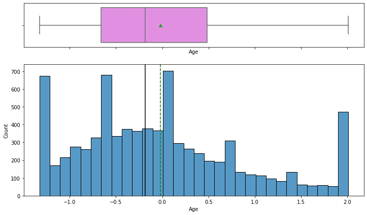

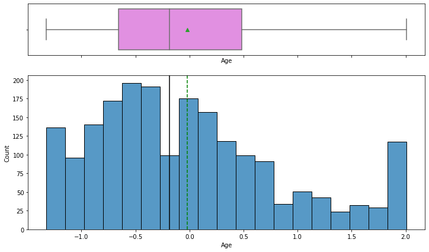

```python
# This is a good time to cap the outliers for Age column. We need to do it separately for the X_train and the
# X_test in order to avoid data leakage.

X_train = cap_outliers(X_train, 'Age')
X_test = cap_outliers(X_test, 'Age')

# Also verify that the data has been capped
histogram_boxplot(X_train, 'Age')
histogram_boxplot(X_test, 'Age')
```

## **Utility function - drawing confusion matrix**

This function has been taken from the code used in MLS session. I found it more useful than creating my own.

```python
def make_confusion_matrix(cf,
                          group_names=None,
                          categories='auto',
                          count=True,
                          percent=True,
                          cbar=True,
                          xyticks=True,
                          xyplotlabels=True,
                          sum_stats=True,
                          figsize=None,
                          cmap='Blues',
                          title=None):
    '''
    This function will make a pretty plot of an sklearn Confusion Matrix cm using a Seaborn heatmap visualization.
    Arguments
    '''


    # CODE TO GENERATE TEXT INSIDE EACH SQUARE
    blanks = ['' for i in range(cf.size)]

    if group_names and len(group_names)==cf.size:
        group_labels = ["{}\n".format(value) for value in group_names]
    else:
        group_labels = blanks

    if count:
        group_counts = ["{0:0.0f}\n".format(value) for value in cf.flatten()]
    else:
        group_counts = blanks

    if percent:
        group_percentages = ["{0:.2%}".format(value) for value in cf.flatten()/np.sum(cf)]
    else:
        group_percentages = blanks

    box_labels = [f"{v1}{v2}{v3}".strip() for v1, v2, v3 in zip(group_labels,group_counts,group_percentages)]
    box_labels = np.asarray(box_labels).reshape(cf.shape[0],cf.shape[1])


    # CODE TO GENERATE SUMMARY STATISTICS & TEXT FOR SUMMARY STATS
    if sum_stats:
        #Accuracy is sum of diagonal divided by total observations
        accuracy  = np.trace(cf) / float(np.sum(cf))

        #if it is a binary confusion matrix, show some more stats
        if len(cf)==2:
            #Metrics for Binary Confusion Matrices
            precision = cf[1,1] / sum(cf[:,1])
            recall    = cf[1,1] / sum(cf[1,:])
            f1_score  = 2*precision*recall / (precision + recall)
            stats_text = "\n\nAccuracy={:0.3f}\nPrecision={:0.3f}\nRecall={:0.3f}\nF1 Score={:0.3f}".format(
                accuracy,precision,recall,f1_score)
        else:
            stats_text = "\n\nAccuracy={:0.3f}".format(accuracy)
    else:
        stats_text = ""


    # SET FIGURE PARAMETERS ACCORDING TO OTHER ARGUMENTS
    if figsize==None:
        #Get default figure size if not set
        figsize = plt.rcParams.get('figure.figsize')

    if xyticks==False:
        #Do not show categories if xyticks is False
        categories=False


    # MAKE THE HEATMAP VISUALIZATION
    plt.figure(figsize=figsize)
    sns.heatmap(cf,annot=box_labels,fmt="",cmap=cmap,cbar=cbar,xticklabels=categories,yticklabels=categories)

    if xyplotlabels:
        plt.ylabel('True label')
        plt.xlabel('Predicted label' + stats_text)
    else:
        plt.xlabel(stats_text)

    if title:
        plt.title(title)
```

```python
# Let me define a handy function that will use the model to do a prediction and then
# convert the probablity result into a 0 or 1.

def get_prediction(model, X_test):
  y_pred1 = model.predict(X_test)
  for i in range(len(y_test)):
    if y_pred1[i]>=0.5:
        y_pred1[i]=1
    else:
        y_pred1[i]=0

  return y_pred1
```

## **Time To Make the Neural Network**

We have 11 independent variables in our data, hence we will need 11 nodes in our input layer of the neural network.

#### **First build the model - Model #1**

```python
#initialize the model
model = Sequential()
```

```python
# This adds the input layer (by specifying input dimension) AND the first hidden layer (units)
model.add(Dense(units=11, input_dim = 11,activation='relu'))   # input of 11 columns as shown above

# hidden layers
model.add(Dense(units=11,activation='relu'))
model.add(Dense(units=11,activation='relu'))
model.add(Dense(units=11,activation='relu'))

# Adding the output layer
# Using the sigmoid activation function in order to get a probability output representing 0 or 1.
model.add(Dense(1,activation='sigmoid'))                        # binary classification
```

```python
# Create optimizer with default learning rate
# Compile the model
model.compile(optimizer='adam',loss='binary_crossentropy',metrics=['accuracy'])
```

```python
# Let's see what the model looks like
model.summary()
```

```
Model: "sequential_18"
_________________________________________________________________
Layer (type)                 Output Shape              Param #
=================================================================
dense_69 (Dense)             (None, 11)                132
_________________________________________________________________
dense_70 (Dense)             (None, 11)                132
_________________________________________________________________
dense_71 (Dense)             (None, 11)                132
_________________________________________________________________
dense_72 (Dense)             (None, 11)                132
_________________________________________________________________
dense_73 (Dense)             (None, 1)                 12
=================================================================
Total params: 540
Trainable params: 540
Non-trainable params: 0
_________________________________________________________________
```

#### **Then train the model**

The training process already has the means to split the data further into train and validation.

```python
history=model.fit(X_train,y_train,batch_size=15,epochs=10,validation_split=0.2)
```

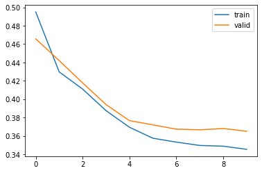

```python
# Capture the learning history per epoch
hist  = pd.DataFrame(history.history)
hist['epoch'] = history.epoch

# Plotting accuracy at different epochs to see how the learning progressed and error dropped with each epoch.
plt.plot(hist['loss'])
plt.plot(hist['val_loss'])
plt.legend(("train" , "valid") , loc=0)
```

Looks like the learning mostly completed by epoch 8, and there wasn't much reduction of errors after that.

#### **Finally test the model with test data**

```python
score = model.evaluate(X_test, y_test)
```

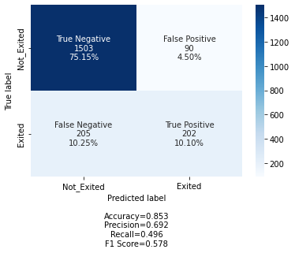

```python
matrix_1=confusion_matrix(y_test, get_prediction(model, X_test))
labels = ['True Negative','False Positive','False Negative','True Positive']
categories = [ 'Not_Exited','Exited']
make_confusion_matrix(matrix_1,
                      group_names=labels,
                      categories=categories,
                      cmap='Blues')
```

### **What measure is important?**

We are trying to predict which of the bank's customers are at risk of switching banks and going to a competitor. In order to prevent this from happening, the bank needs to engage with the customers who are at risk of switching.

This means that bank needs to

- maximize the True positives (predicted to switch and actually will switch)
- minimize the False negatives (bank predicts they will not switch but they actually do)

We will need to evaluate the quality of the model by creating a confusion matrix and maximizing the recall score.

In this case, we got a **Recall score of 0.496**, which is really low.

### **Model Improvement through ROC-AUC**

[figure not shown]

```python
logit_roc_auc_train = roc_auc_score(y_train, get_prediction(model, X_train))
fpr, tpr, thresholds = roc_curve(y_train, get_prediction(model, X_train))
plt.figure(figsize=(7,5))
plt.plot(fpr, tpr, label='Logistic Regression (area = %0.2f)' % logit_roc_auc_train)
plt.plot([0, 1], [0, 1],'r--')
plt.xlim([0.0, 1.0])
plt.ylim([0.0, 1.05])
plt.xlabel('False Positive Rate')
plt.ylabel('True Positive Rate')
plt.title('Receiver operating characteristic')
plt.legend(loc="lower right")
plt.show()
```

```python
# Optimal threshold as per AUC-ROC curve
# The optimal cut off would be where tpr is high and fpr is low
fpr, tpr, thresholds = metrics.roc_curve(y_test, get_prediction(model, X_test))

optimal_idx = np.argmax(tpr - fpr)
optimal_threshold_auc_roc = thresholds[optimal_idx]
print(optimal_threshold_auc_roc)
```

```
1.0
```